# Stack Overflow Analysis

Marcos Garcia

2023-05-18

## Initial Steps

```r
#Setting a global variable for my data
load("myWorkSpace.RData")
MyData <- survey_results_public_correct
```

## Where did people take the Survey from

In this analysis, we want to know where the survey responses came from. To do so, we will first clean the data, then analyze it by counting the number of responses from each country, and finally visualize the top 30 countries using a treemap.

**Step 1: Data Cleaning**

```r
# First, we define our color palette using RColorBrewer
color_palette <- brewer.pal(8, "Set3")

# Clean the Country data in 'MyData' dataframe
# Trim leading or trailing white spaces
MyData$Country <- trimws(MyData$Country)

# Replace any missing country values with "Unknown"
MyData$Country[is.na(MyData$Country)] <- "Unknown"
```

**Step 2: Data Processing**

```r
# Count the number of responses from each country
country_counts <- table(MyData$Country)

# Convert the table to a data frame for easier manipulation and plotting
country_counts_df <- as.data.frame(country_counts)
names(country_counts_df) <- c("Country", "Count")

# Filter the data to get the top 30 countries
top_countries <- country_counts_df[order(-country_counts_df$Count),][1:30,]
```

**Step 3: Data Visualization**

```r
# Create a new color palette for our visualization
color_palette <- brewer.pal(8, "Set2")

# Use the 'treemap' function to create a treemap of the top 30 countries
treemap(
  top_countries,
  index = c("Country", "Count"),
  vSize = "Count",
  title = "Top 30 Countries where the results are from",
  fontsize.labels = c(15, 12),
  fontcolor.labels = c("white", "white"),
  align.labels = list(c("center", "center"), c("right", "bottom")),
  overlap.labels = 0.5,
  inflate.labels = F,
  palette = color_palette
)
```

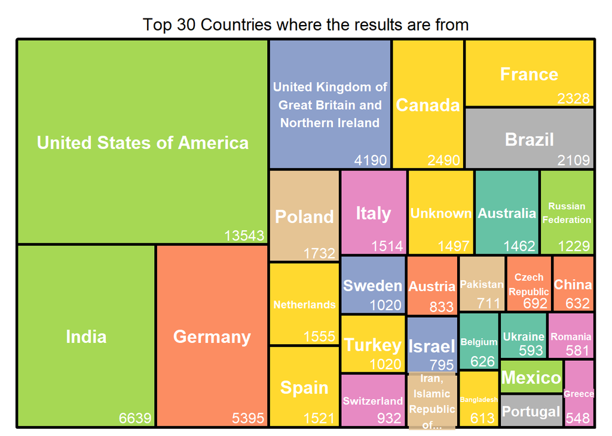

## Top 10 Most Popular Programming languages

In this analysis, we aim to find the top 10 programming languages used by respondents in our survey data. The analysis will be done in three steps: data transformation, data analytics, and data visualization.

**Step 1: Data Transformation**

```r
# Split the 'LanguageHaveWorkedWith' column at every semicolon
split_langs <- strsplit(MyData$LanguageHaveWorkedWith, split = ";")

# Unlist to create a single vector of languages
unlisted_langs <- unlist(split_langs)
```

**Step 2: Data Processing**

```r
# Count the number of times each language appears
lang_counts <- table(unlisted_langs)

# Calculate the total count of all languages
total_count <- sum(lang_counts)

# Sort in descending order and take the top 10
top_langs <- sort(lang_counts, decreasing = TRUE)[1:10]

# Convert to data frame for plotting
top_langs_df <- as.data.frame(table(unlisted_langs))
names(top_langs_df) <- c("language", "count")

# Filter to only include top languages
top_langs_df <- top_langs_df[top_langs_df$language %in% names(top_langs), ]

# Calculate percentages
top_langs_df$percentage <- (top_langs_df$count / total_count) * 100

# Reorder languages by count in ascending order for better visualization
top_langs_df$language <- factor(top_langs_df$language, levels = rev(names(top_langs)))
```

**Step 3: Data Visualization**

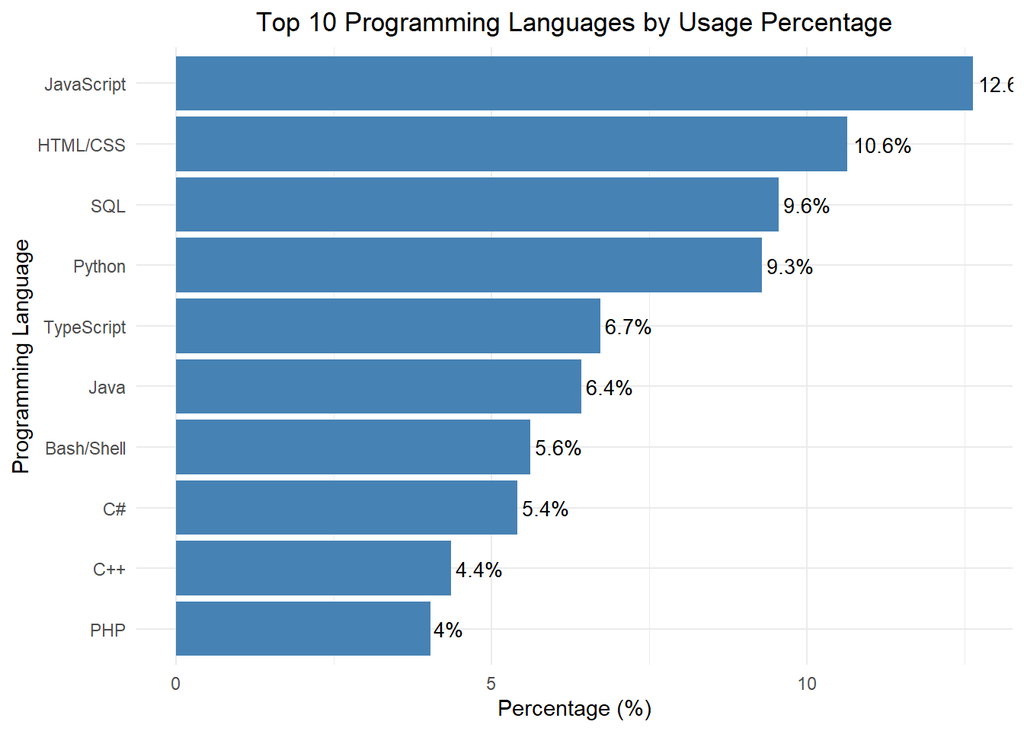

```r
# Plot a horizontal bar chart of the top languages by usage percentage
ggplot(top_langs_df, aes(y = language, x = percentage)) +
  geom_bar(stat = "identity", fill = "steelblue") +
  geom_text(aes(label = paste0(round(percentage, 1), "%")), hjust = -0.1, size = 3.5) +
  labs(y = "Programming Language", x = "Percentage (%)", title = "Top 10 Programming Languages by Usage Percentage") +
  theme_minimal() + theme(plot.title = element_text(hjust = 0.5))
```

This process results in a clear bar chart that displays the top 10 programming languages based on usage percentages among survey respondents.

## Top 10 Programing Languages Developers want to use

In this analysis, our objective is to determine the top 10 programming languages that developers are interested in learning in 2023. We will carry out this analysis in three main steps: data transformation, data analytics, and data visualization.

**Step 1: Data Cleaning**

```r
# Split the 'LanguageWantToWorkWith' column at every semicolon
split_langs1 <- strsplit(MyData$LanguageWantToWorkWith, split = ";")

# Unlist to create a single vector of languages
unlisted_langs1 <- unlist(split_langs1)
```

**Step 2: Data Processing**

```r
# Count the number of times each language appears
lang_counts1 <- table(unlisted_langs1)

# Calculate the total count of all languages
total_count1 <- sum(lang_counts1)

# Sort in descending order and take the top 10
top_langs1 <- sort(lang_counts1, decreasing = TRUE)[1:10]

# Convert to data frame for plotting
top_langs_df1 <- as.data.frame(table(unlisted_langs1))
names(top_langs_df1) <- c("language", "count")

# Filter to only include top languages
top_langs_df1 <- top_langs_df1[top_langs_df1$language %in% names(top_langs1), ]

# Calculate percentages
top_langs_df1$percentage <- (top_langs_df1$count / total_count1) * 100

# Reorder languages by count in ascending order for better visualization
top_langs_df1$language <- factor(top_langs_df1$language, levels = rev(names(top_langs1)))
```

**Step 3: Data Visualization**

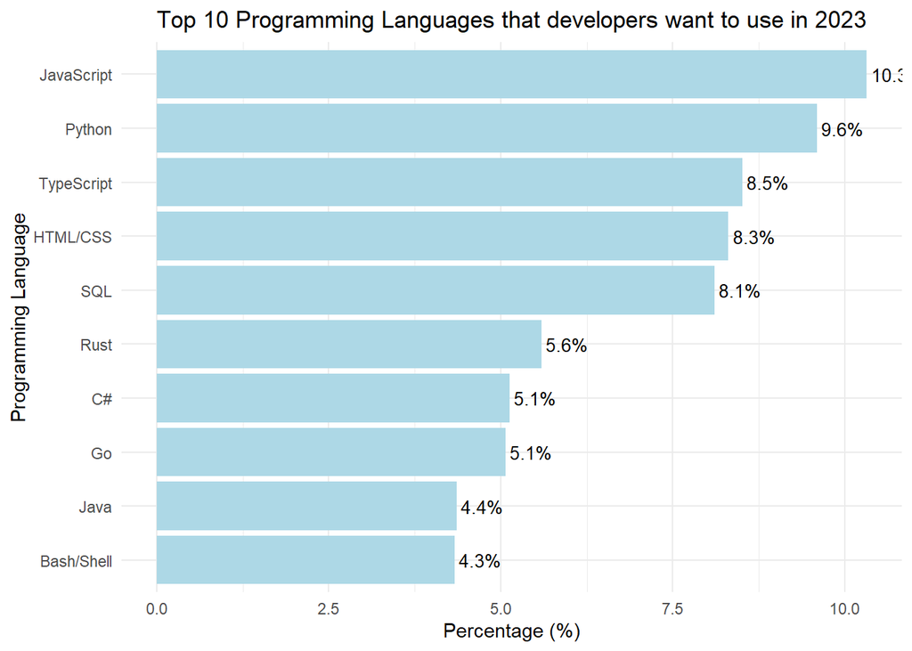

```r
# Plot a horizontal bar chart of the top languages that developers want to use in 2023
ggplot(top_langs_df1, aes(y = language, x = percentage)) +
  geom_bar(stat = "identity", fill = "lightblue") +
  geom_text(aes(label = paste0(round(percentage, 1), "%")), hjust = -0.1, size = 3.5) +
  labs(y = "Programming Language", x = "Percentage (%)", title = "Top 10 Programming Languages that developers want to use in 2023") +
  theme_minimal() + theme(plot.title = element_text(hjust = 0.5))
```

This process generates a bar chart displaying the top 10 programming languages that developers are interested in learning based on their share of mentions among survey respondents.

## How many respondents are working remotely

In this analysis, we want to examine the distribution of work modes among our survey respondents. This will be done in three main steps: data cleaning, data analytics, and data visualization.

**Step 1: Data Cleaning**

```r
# Remove rows where the 'RemoteWork' field is NA or blank
MyData <- MyData[!is.na(MyData$RemoteWork) & MyData$RemoteWork != "",]
```

**Step 2: Data Processing**

```r
# Get counts of each category
remote_counts <- table(MyData$RemoteWork)

# Convert to data frame for plotting
remote_counts_df <- as.data.frame(remote_counts)
names(remote_counts_df) <- c("RemoteWork", "Count")
```

**Step 3: Data Visualization**

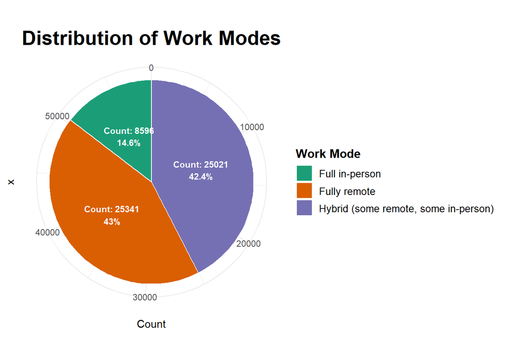

```r
# Create a pie chart to visualize the distribution of work modes
ggplot(remote_counts_df, aes(x = "", y = Count, fill = RemoteWork)) +
  geom_bar(width = 1, stat = "identity", color = "white") +
  coord_polar("y", start = 0) +
  scale_fill_brewer(palette = "Dark2") +
  theme_minimal() +
  labs(title = "Distribution of Work Modes", fill = "Work Mode") +
  theme(
    plot.title = element_text(hjust = 0.5, size = 20, face = "bold"),
    legend.title = element_text(size = 12, face = "bold"),
    legend.text = element_text(size = 10)
  ) +
  geom_text(
    aes(label = paste0(
      "Count: ", Count, "\n", round(Count / sum(Count) * 100, 1), "%"
    )),
    position = position_stack(vjust = 0.5),
    size = 3,
    color = "white",
    fontface = "bold"
  )
```